# Bienvenue au restaurant *Le Fossile*, qu’allez-vous manger ce soir ?

Chahwan, Ndaya Nsabua, Delpont

2025-01-09

# Introduction

- Objectif du projet :
  - Déterminer le type de personnalité de l’utilisateur
  - Proposer un menu personnalisé
- Méthodologie :
  - Recherche des données & Création des bases de données
  - Test de personnalité
  - Sélection

# Construction de la base de données

## Méthode considérées & problèmes envisagés

Utiliser une IA (e.g. Gemini, ChatGPT) pour créer une base de donnée à partir du fichier d’un menu (PDF). La réponse serait demandée sous format CSV ou XLS. - Méthodes :

- API (e.g. OpenAI) –> payante
- Integration d’une NLP open source (comme Stanford NLP Group) dans R
  - Problème : Mauvaise version de Java
- Création d’un bot qui fait une requette à une IA
  - L’IA propose des réponses non standards
  - Nécessiterait un bot plus avancé pour identifier la bonne information dans le message

# Construction de la base de données

## Méthode adoptée

Créer notre propre base de donnée en se basant sur le menu du restaurant strasbourgois **Le Fossile**.

# Importation des Données

- Les fichiers utilisés :
  - Descriptions des plats : caractéristiques des desserts, viandes, boissons, etc.
  - Menus triés par type (entrées, viandes, desserts, boissons).
- Formats utilisés : Excel.
- Exemple de structure de données :

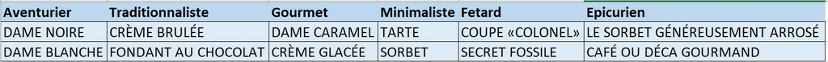

Base de données des desserts triées par personnalité

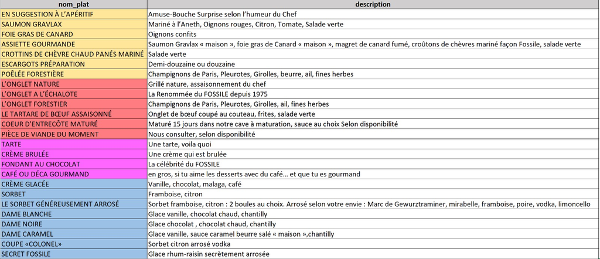

Base de données des plats avec leurs descriptions

## Test de personnalité.

Nous avons déterminé 6 types de personnalité :

- Aventurier
- Traditionnaliste
- Gourmet
- Minimaliste
- Fêtard
- Épicurien

## Déroulé du test

Le programme propose 7 affirmations, par exemple :

- *1. Vous aimez explorer des endroits inconnus, même sans plan précis.*
- *2. Vous trouvez du confort dans les routines bien établies et les traditions.*

Exemple de ce à quoi le code ressemble pour l’utilisateur :

```
> # Poser les questions et calculer les scores
> for (i in seq_along(questions)) {
+   response <- ask_question(questions[i])
+   for (personality in  .... [TRUNCATED]
1. Vous aimez explorer des endroits inconnus, même sans plan précis.
Répondez par : 1 = D'accord, 2 = Plutôt d'accord, 3 = Indifférent,
4 = Plutôt en désaccord, 5 = En désaccord

Votre réponse : 1
```

## Le Système de poids

Chaque personnalité est associée à un vecteur de poids :

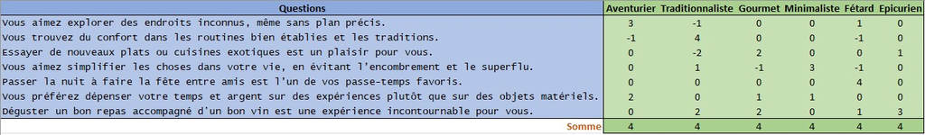

Erreur que nous avons fait :

- Somme des poids des personnalités inégales

## Calcul des scores

On fait donc la somme pondérée des réponses pour chaque personnalité. Puis tri des personnalités en fonction de leur score :

- Personnalité avec le plus haut score : `main_personnality`
- Personnalité avec le second plus haut score : `secondary_personnality`

```
Votre personnalité principale est : Fetard - Vous aimez profiter des
moments festifs entre amis, sortir, et vivre pleinement la vie sociale.

On dirait que vous avez un petit côté caché qui se manifeste en vous ! Votre
personnalité secondaire est : Aventurier - Vous êtes curieux(se) et aimez
explorer de nouvelles expériences et lieux, souvent sans plan précis. Vous
vivez pour l’excitation et la découverte.
```

## Sélection des plats en fonction de la personnalité

Dans cette partie, le code propose des entrées, des plats et desserts en fonction de la personnalité principale `[main_personality]` d’un utilisateur. Les recommandations sont enrichies par des descriptions.

### 1.Recommandation des plats

#### *Extraction des données*

On vérifie si `[main_personality]` correspond à une colonne du dataframe `(Entrees_triees)`, `(Desserts_triees)` ou `(Viandes_triees)`. Si oui, les plats associés à cette personnalité sont extraites et les valeurs manquantes sont éliminées avec `na.omit()`.Et les plats sont affichées à l’utilisateur

#### *Explications*

Si l’utilisateur le souhaite (réponse `"Oui"`), des descriptions des plats sont recherchées dans le dataframe `Description_plats` est affichées

Exemple code avec les entrées :

```
selected_entrees <-Entrees_triees[[main_personality]]
selected_entrees <- na.omit(selected_entrees)
entrees_descriptions <- Description_plats[Description_plats$nom_plat %in% selected_entrees, ]
```

### 2.Recommandation des boissons

#### *Filtrage par alcool*

L’utilisateur indique s’il souhaite consommer de l’alcool. Selon sa réponse , les boissons correspondantes sont filtrées dans le dataframe `Boissons_triees` (en fonction de la colonne Alcool).

#### *Personnalité secondaire*

Les boissons sont filtrées en fonction de `secondary_personality`, contrairement aux plats qui l’étaient en fonction de `main_personality` Si demandé, des descriptions des boissons sont affichées.

### 3.Gestion des erreurs

Si la personnalité (secondary_personality ou main_personality)n’est pas trouvée dans les colonnes des dataframes, un message d’erreur est affiché pour informer l’utilisateur

Si aucune description n’est disponible, un message est affiché pour informer l’utilisateur

### 4.Fonctionnalités interactives

Le programme utilise readline() pour obtenir des réponses de l’utilisateur de manière interactive :

Si l’utilisateur souhaite des explications sur les plats.

Si l’utilisateur souhaite consommer de l’alcool pour les boissons.

Code :

```
response <- readline(prompt = "Souhaitez-vous des explications sur ces plats ? (Oui/Non) : ")

  if (tolower(response) == "oui") {
    # Rechercher les descriptions
    ...
```

## Conclusion :

Force :

- Flexibilité du code grâce au 6 personnalités différentes.
- Pourrait être adapté à n’importe quel restaurant ou test de personnalité.

Limites :

- Bases de données créées manuellement donc de taille limitée.